# Coursework Report

*N* removed NAs: 2

*N* removed <18: 31

*N* total clean: 115

| Group | *N* | *M*<sub>age</sub> | *M*<sub>rating</sub> |
| --- | --- | --- | --- |
| Control | 60 | 21.15 | 6.08 |
| Experim | 55 | 20.51 | 7.30 |

**Main analysis results**

*t*(113) = -8.21, *p* < .001

# Coursework Report

Analysing Data, Spring 2020

# Methods

## Participants

Table 1 *Participant descriptives by condition*

| Condition | Age M | Age SD | Age Min | Age Max | Age Range | N |
| --- | --- | --- | --- | --- | --- | --- |
| White | 21.15 | 2.17 | 18 | 28 | 10 | 60 |
| Red | 20.51 | 1.88 | 18 | 26 | 8 | 55 |

## Design

The conceptual hypothesis that was examined in this study was that colour affects attractiveness, specifically, if the colour red increases how attractive a woman finds a man.

Every participant viewed a 4-in. x 6-in. black-and-white image of a Caucasian man’s head and torso. Participant’s either viewed the image surrounded by a white background (n = 60), the control, or a red background (n = 55), the experimental group. After 5 seconds of viewing the image, each participant filled out perceived attractiveness ratings for three questions. The three questions were: “How attractive do you think this person is?”, “How pleasant is this person to look at?” and “If I were to meet the person in this picture face to face, I would think he is attractive”. Each question was rated on a 9-point scale, where 1 was “not at all” and 9 was “extremely”. The scores for the three questions were averaged together to get a composite score. (Elliot, Niesta Kayser, Greitemeyer, Lichtenfield, Gramzow, Maier, 2010).

The predictor in the study was the manipulation of colour, this was the independent categorical variable as it was manipulated whether the participant would view the image on a red background or a white background. The dependent variable (the outcome) was how attractive they perceived the man in the image to be. From this, our operationalised hypothesis would be that if a female viewed a black-and-white image of a moderately attractive Caucasian male on a red background, then they will perceive this male as more attractive than a picture of a male on a background with no colour (white). How attractive they perceive the male to be will be based on a composition of mean ratings (from a 9-point scale) from three questions about the man’s perceived attractiveness. In order to test the significance of our results, an independent-measures *t*-test will be used with a 95% confidence interval.

# Results

The ratings for perceived attractiveness were compiled from all three questions. The mean rating across the three questions were compiled for each participant. Additionally, we calculated the mean rating and standard deviation for each question in both the control group and the experimental group. A composite mean score for all three questions in each group was then compiled. This involves adding up the mean rating for each question and then dividing that by three, the number of questions. Table 2 shows the composite mean and standard deviation for each question, as well as the number of participants and the composite mean score, which were all grouped by colour.

Table 2 *Question descriptives by condition*

| Condition | Question 1 M | Question 1 SD | Question 2 M | Question 2 SD | Question 3 M | Question 3 SD | N | Composite mean |
| --- | --- | --- | --- | --- | --- | --- | --- | --- |
| White | 5.92 | 1.28 | 6.12 | 1.33 | 6.20 | 1.57 | 60 | 6.08 |
| Red | 7.22 | 1.30 | 7.18 | 1.35 | 7.51 | 1.20 | 55 | 7.30 |

This table shows that the experimental group had higher mean ratings than the control across all three questions. Due to thus, the composite mean score was lower in the control group than in the experimental group, as can be seen in Table 2. This suggests a general pattern that those who viewed the image of the man on a red background (*M* = 7.3), rather than a white background (*M* = 6.08), perceived him as more attractive. Additionally, the standard deviation in all three questions were relatively similar across both groups, however the standard deviation for the control group in question 3 seems to be relatively higher than the standard deviation for the experimental group, suggesting that the results for question 3 were spread out more around the mean for the control than they were in the experimental group. Furthermore, the fact that every standard deviation is greater than 1 does suggest that the scores are spread relatively widely around the mean, which could threaten the reliability of the scores.

Figure 1 shows a means plot for the composite mean scores in each condition and shows a difference in mean scores suggesting that the perceived attractiveness of the man was higher in the red condition.

**Figure 1.** *Means plot for composite mean scores in both colour conditions*

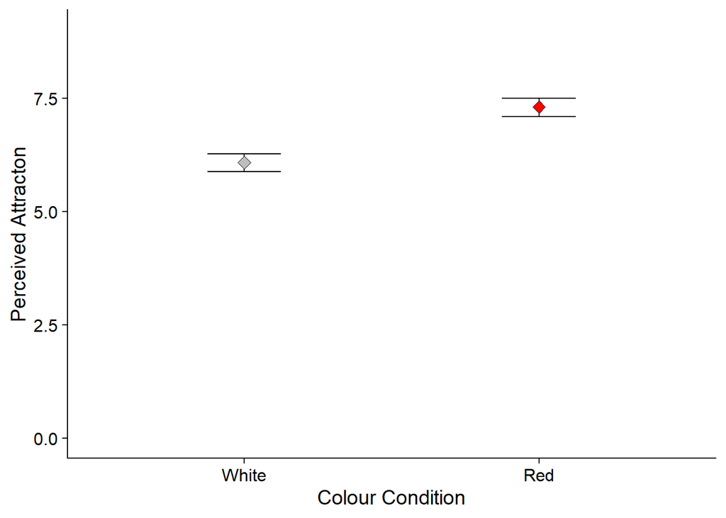

# Discussion

The present research allowed us to examine whether the colour red was associated with how attractive a woman perceives a man to be. It was found that those who saw the image of the man in the red condition generally rated the man as more attractive, across three questions, than those participants in the white condition (without any colour present). We used an independent measures *t*-test to test if our results were significant with a 95% confidence interval. The test indicated that the difference in composite means, between both conditions, was statistically significant and not due to chance, thus supporting the hypothesis and suggesting that there is an association between the colour red and an increase in participants’ ratings of attractiveness.

The present study acted as a replication of a study by Elliot et al. (2010). The pattern of results that they found were similar to ours and thus supported their hypothesis. Additionally, they also conducted an independent-measures *t*-test and found the difference in means to be significant. The fact that both the original study and our replication show similar results suggests that our conclusion is reliable. Additionally, Elliot et al. (2010) conducted a number of other experiments testing the association between the colour red and increasing ratings of perceived attractiveness, as well as status. They found that the colour red, across all additional experiments, was associated with an increased perception attractiveness. Furthermore, some of these experiments were also conducted with men perceiving the attractiveness of women, which suggests that this effect may not just be seen in women. However, other studies that have examined the colour red and its association with perceived attractiveness have found opposing results. One such example of this was a replication of Elliot et al.’s (2010) study; conducted by Hesslinger, Goldbach and Carbon (2015). This replication was done with a larger sample, but they did not find that the colour red had any effect on how participants perceived attractiveness. This study thus throws into question the validity, and reliability of results, of both the present research and Elliot et al.’s study. Additionally, a study by Peperkoorn, Roberts and Pollet (2016) looked at the effect of the colour red in both short-term (casual sex) and long-term mating (relationship) contexts. They hypothesised that women dressed in red would be perceived as the most sexually attractive in a short-term, as well as a long-term, context compared to those in white or black. The colour red was found to not increase the sexual attractiveness of women. Additionally, the fact that this study also used similar, although not the same, perceived attractiveness questions as the present study (“‘how attractive do you think this woman is?’’ and ‘‘how pretty do you think this woman is?’’) also reduces the reliability of the present research. However, it could be suggested that the reason no association between the colour red and higher ratings of attractiveness were found may be due to the colour being placed in a different context (the colour was on their clothing rather than surrounding a picture). Additionally, these experiments exclusively looked at male ratings of women, whereas our research looked at female ratings of men, which could suggest why there was a difference in findings. Due to this difference, it may be worth while conducting an additional study where women rate the attractiveness of men in red clothing, in the conditions set out by Peperkoorn et al. (2016). Also, it may be worth conducting a replication of the present study but with a sample of men rating the perceived attractiveness of pictures of women with a red background.

There are several limitations with the present research, which may prevent us from achieving reliable, and valid, results. The fact that the present research used a red background, instead of red clothing, could lead to the suggestion that the study lacks ecological validity. This is because in a real-life setting when someone is perceiving another to be attractive or not, the colour red may not be as prominent in the background as it was in the study. It could be said that the prominence of the colour may have had the effect on perceived attractiveness rather than the colour red itself. Another way in which this study may lack ecological validity was pointed out by Hesslinger et al. (2015). They suggested that because the image was only of the upper torso and head, that important features which may increase attractiveness, such as height or clothing, were neglected. Hesslinger et al. (2015) thus conducted another study using pictures of 32 full-body men in either casual or formal attire. The images were, similarly to the present research, placed on either a red or white background and the female participants were asked to rate the attractiveness of the men. They found no red effect on attractiveness but did find that the type of clothing had an effect. By neglecting an important factor, such as clothing, the present research can be suggested to be lacking external validity and it could be said that other factors, rather than just colour, should be explored.

Due to the neglect of other important features in the present research, it may be worth looking at other features in conjunction with colour. These could include looking at the use of glasses, make-up and different clothing styles. Additionally, these should be employed in conjunction with the colour red as well as other colours, for example orange or green, in order to see if it is due to the colour red or if it is just the presence of any colours at all. Also, it may be worth looking at other populations with other genders and sexualities other than just heterosexual women, for example homosexual and bisexual men and women or those who are non-binary. Another interesting field to look into may be the biological evidence for the colour red having an impact on perceived attractiveness. It may be worth looking into using an fMRI when participants view the images with the different colours to see if there is a biological reason behind the impact of colour. Specifically, looking at the activation of the anterior cingulate cortex may be a path to go down due to the ACC being involved in sexual arousal (Wu, Kim, Li, Zhang and Zhuo (2009).

In conclusion, the present research strove to look at if the colour red affects how attractive a woman perceives a man to be. It was found that participants who viewed the man on a red background perceived the man as more attractive than those who viewed the man on a white background. These results did line up with Elliot et al.’s results, which the present research was a replication of, thus giving our results some reliability. However, several studies have found opposing results, including that the colour red has no impact on perceived attractiveness (Peperkoorn et al. 2016; Hesslinger et al. 2015), thus putting our results into some question. Furthermore, it may be worth looking further into other factors affecting attractiveness, including clothing and make-up. Additionally, it may be worth looking at the biological implications of the colour red.

# References

Elliot, A. J., Kayser, D. N., Greitemeyer, T., Lichtenfeld, S., Gramzow, R. H., Maier, M. A., & Liu, H. (2010). Red, rank, and romance in women viewing men. *Journal of Experimental Psychology: General*, 139(3), 399–417.

context: A reply to Francis (2013). *Journal of Experimental Psychology: General*, Vol. 142, Iss. 1.

Francis, G. (2013). Publication bias in “Red, rank, and romance in women viewing men,” by Elliot et al. (2010). *Journal of Experimental Psychology: General*, Vol. 142, Iss. 1.

Hesslinger, V. M., Goldbach, L., & Carbon, C.-C. (2015). Men in red: A reexamination of the red-attractiveness effect. *Psychonomic Bulletin & Review*, 22(4), 1142–1148.

Peperkoorn, L. S., Roberts, S. C., & Pollet, T. V. (2016). Revisiting the Red Effect on Attractiveness and Sexual Receptivity: No Effect of the Color Red on Human Mate Preferences. *Evolutionary Psychology*, 14(4), 147470491667384.

Wu, L.-J., Kim, S. S., Li, X., Zhang, F., & Zhuo, M. (2009). Sexual attraction enhances glutamate transmission in mammalian anterior cingulate cortex. *Molecular Brain*, 2(1), 9.